# IODS course project

Tutkin seuraavaksi suuren alkoholinkäytön joka on looginen muuttuja yhteyttä terveyteen, poissaoloihin, opiskeluun käytettyyn aikaan ja sukupuoleen. Hypoteesini on että terveys ja suuri alkoholinkäyttö korreloivat negatiivisesti. Arvioin myös että opiskeluun käytetyllä ajalla ja suurella alkoholinkäytöllä on negatiivinen korrelaatio. Arvioin myös että poissaolot ja suuri alkoholinkäyttö korreloivat positiivisesti. Hypoteesini on että sukupuoli vaikuttaa suureen alkoholinkäyttöön niin että miehissä on enemmän heitä jotka käyttävät paljon alkoholia eli heitä joille high_use-muuttuja saa arvon TRUE.

```r
table(health,high_use)
```

```
##       high_use
## health FALSE TRUE
##      1    35   11
##      2    28   16
##      3    62   19
##      4    49   18
##      5    94   50
```

```r
table(absences,high_use)
```

```
##         high_use
## absences FALSE TRUE
##       0     52   13
##       1     38   13
##       2     42   16
##       3     33    8
##       4     24   12
##       5     16    6
##       6     16    5
##       7      9    3
##       8     14    6
##       9      6    6
##       10     5    2
##       11     2    4
##       12     4    4
##       13     1    1
##       14     1    6
##       16     0    1
##       17     0    1
##       18     1    1
##       19     0    1
##       20     2    0
##       21     1    1
##       26     0    1
##       27     0    1
##       29     0    1
##       44     0    1
##       45     1    0
```

```r
table(studytime,high_use)
```

```
##          high_use
## studytime FALSE TRUE
##         1    58   42
##         2   135   60
##         3    52    8
##         4    23    4
```

```r
table(sex,high_use)
```

```
##    high_use
## sex FALSE TRUE
##   F   156   42
##   M   112   72
```

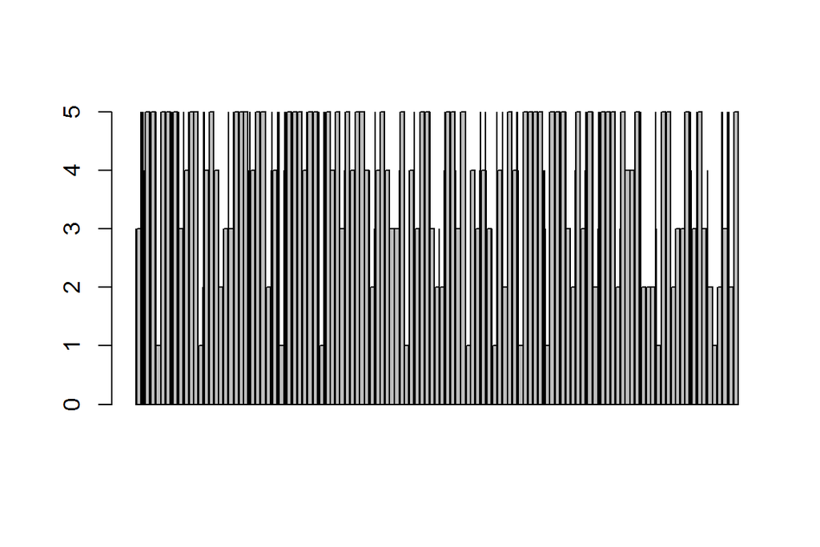

```r
barplot(health,high_use)
```

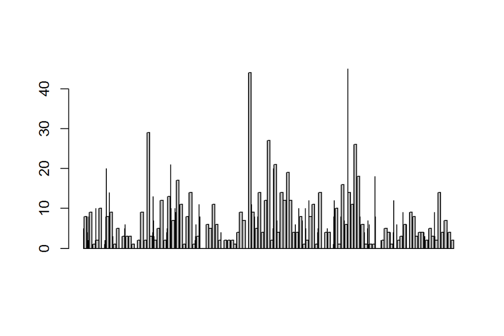

```r
barplot(absences,high_use)
```

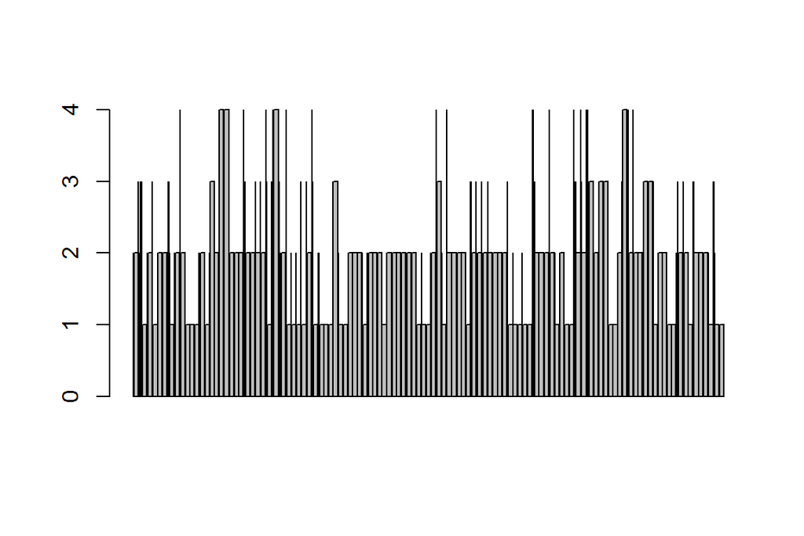

```r
barplot(studytime,high_use)
```

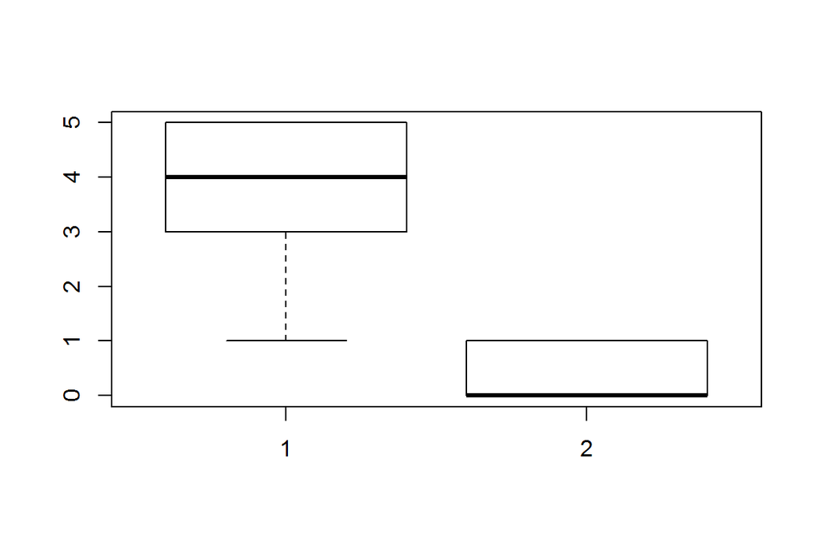

```r
boxplot(health,high_use)
```

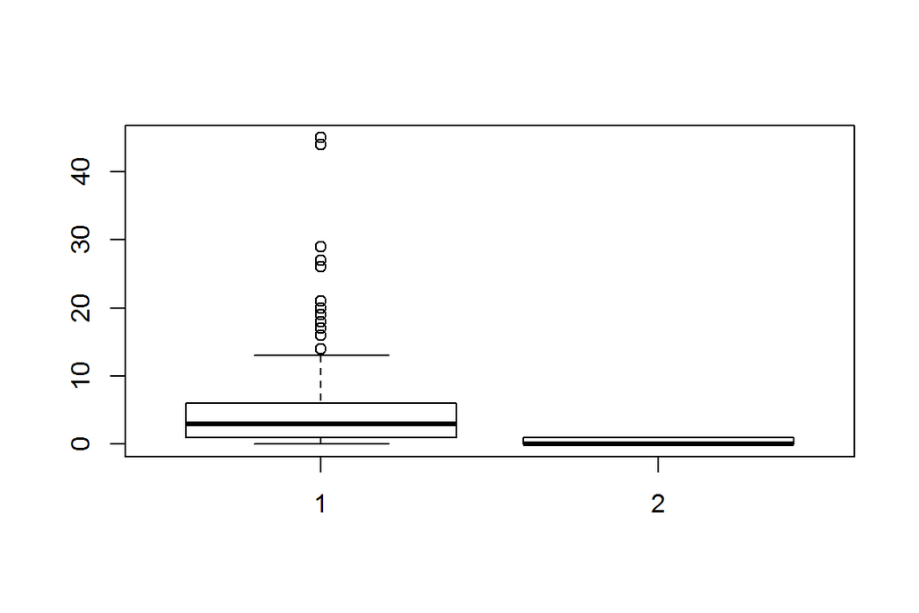

```r
boxplot(absences,high_use)
```

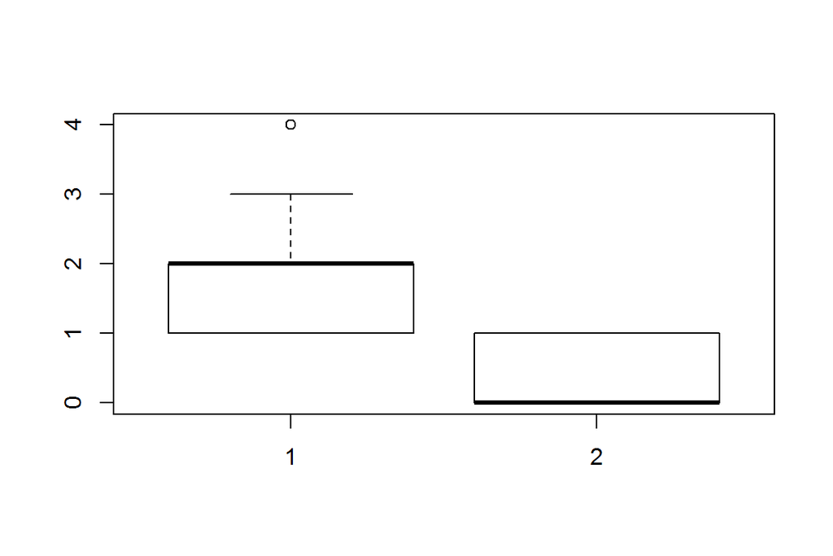

```r
boxplot(studytime,high_use)
```

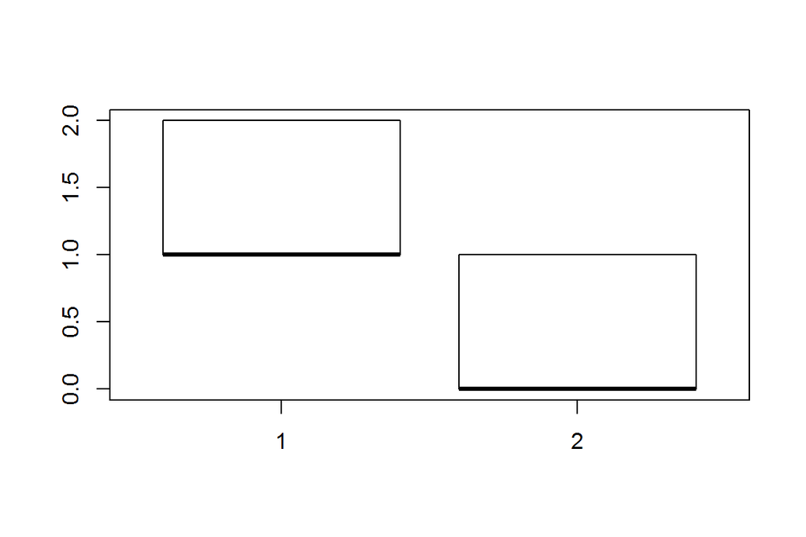

```r
boxplot(sex,high_use)
```

```r
m = glm(high_use ~ health + absences + studytime + sex, data = alc, family = "binomial")

summary(m)
```

```
##
## Call:
## glm(formula = high_use ~ health + absences + studytime + sex,
##     family = "binomial", data = alc)
##
## Deviance Residuals:
##     Min       1Q   Median       3Q      Max
## -2.2074  -0.8367  -0.5983   1.0910   2.1407
##
## Coefficients:
##             Estimate Std. Error z value Pr(>|z|)
## (Intercept) -1.08010    0.52055  -2.075 0.037995 *
## health       0.04493    0.08631   0.521 0.602675
## absences     0.08881    0.02307   3.850 0.000118 ***
## studytime   -0.39817    0.15960  -2.495 0.012603 *
## sexM         0.78234    0.25261   3.097 0.001954 **
## ---
## Signif. codes:  0 '***' 0.001 '**' 0.01 '*' 0.05 '.' 0.1 ' ' 1
##
## (Dispersion parameter for binomial family taken to be 1)
##
##     Null deviance: 465.68  on 381  degrees of freedom
## Residual deviance: 423.00  on 377  degrees of freedom
## AIC: 433
##
## Number of Fisher Scoring iterations: 4
```